# peso_g entre grupos de racao

- Mostrar o código
- Esconder o código
- Ver o código fonte

Caderno completo · da base preparada à comparação dos grupos

Autor

EAPA — Estatística Aplicada à Pesca e Aquicultura com R

Data de Publicação

29 de setembro de 2026

# 1 Como usar este caderno

Este documento acompanha o percurso completo da ANOVA. Os cálculos vivem em `R/analise.R`; os chunks abaixo apenas apresentam os objetos produzidos por ele. As tabelas CSV e as figuras PNG em `saida/` são cópias para consulta e não alimentam o relatório. Cada Render começa em uma sessão nova.

**Os textos são sugestões para estudo e adaptação.** Os números se atualizam com o script, mas a interpretação depende da pergunta, das unidades e do delineamento da pesquisa.

# 2 Introdução: qual comparação queremos investigar?

*Sugestão de redação: adapte a pergunta e acrescente referências do seu tema antes de compartilhar o relatório.*

Na pesca e na aquicultura, comparar grupos é uma das perguntas mais frequentes: rações, densidades, espécies, locais ou épocas. A análise de variância de um fator avalia se a média de uma resposta numérica difere entre os grupos definidos por um fator.

Neste estudo, comparou-se Peso (g) entre os grupos de Tipo de Ração. O objetivo foi verificar se as médias diferem, identificar quais grupos se separam e estimar a magnitude dessa diferença.

# 3 Material e métodos: o que entrou na comparação?

*Sugestão de redação: complete a origem dos dados, o período, o local, a unidade experimental, as unidades de medida e os critérios de seleção. Não declare independência sem conferir o delineamento.*

A comparação de Peso (g) entre os grupos de Tipo de Ração usou análise de variância de um fator, seguida do teste de Tukey, com as funções de base do R (R Core Team, 2025). Foram utilizados os casos com resposta e grupo preenchidos. Os intervalos de confiança das médias e das comparações foram de 95%, e adotou-se nível de significância de 0,05 (Zar, 2010).

A homogeneidade das variâncias foi avaliada pelo teste de Levene, do pacote `car` (Fox & Weisberg, 2019), e a normalidade dos resíduos pelo teste de Shapiro-Wilk, ambos acompanhados dos gráficos de resíduos. As letras de contraste do teste de Tukey foram obtidas com o pacote `multcompView` (Graves et al., 2026), e as figuras foram construídas com o `ggplot2` (Wickham, 2016). O tamanho do efeito foi descrito por η² e ω².

## 3.1 Dados e preparo

A entrada preservada está em `dados/brutos/isoproteica_bagre.xlsx`. A CatalyseR registrou o preparo no início de `R/analise.R` e guardou a base adotada em `dados/processados/base_compartilhada.rds`. O script reconstrói o percurso, confere a base e usa a fotografia adotada para impedir mudanças silenciosas no Render.

Após o preparo, havia 19 observações. A análise utilizou 19 casos completos em 4 grupos; 0 observações foram excluídas por ausência de resposta ou grupo.

## 3.2 Modelo

Ajustou-se uma análise de variância de um fator, seguida do teste de Tukey, com intervalos de confiança de 95%. Os pressupostos foram examinados pelos testes de Shapiro-Wilk e de Levene e pelos gráficos de resíduos.

# 4 Exploração: conhecer os grupos antes do teste

Os números da ANOVA só merecem leitura depois dos pressupostos: variâncias parecidas e resíduos aproximadamente normais são o que dá sentido ao teste F. Por isso esta seção explora os grupos e termina com o diagnóstico dos resíduos, antes de apresentar os resultados.

A Tabela 1 reúne os números de cada grupo e a Figura 1 mostra a distribuição das observações, antes de qualquer teste.

**Ver código de apresentação**

```r
flextable_ocean(tabela_resumo_exibir[, 1:5])
```

Tabela 1: Resumo por grupo antes do teste: tamanho, centro e dispersão.

| Tipo de Ração | n | Média | DP | EP |
| --- | --- | --- | --- | --- |
| A | 5 | 86,20 | 3,11 | 1,39 |
| B | 5 | 88,80 | 3,11 | 1,39 |
| C | 4 | 102,50 | 2,65 | 1,32 |
| D | 5 | 92,60 | 3,05 | 1,36 |

**Ver código de apresentação**

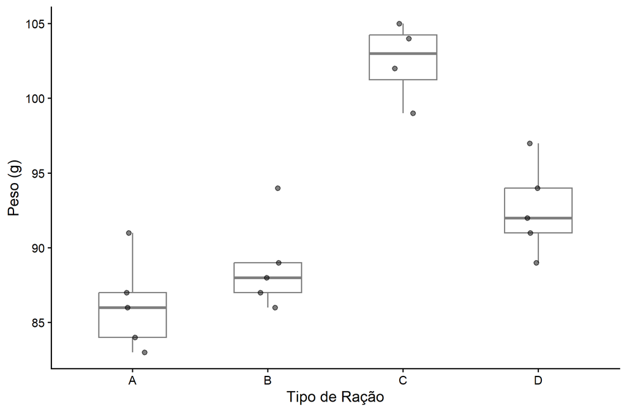

Figura 1: Distribuição da resposta em cada grupo, com as observações sobrepostas.

```r
grafico_boxplot
```

## 4.1 Diagnósticos: até onde podemos confiar no teste F?

### 4.1.1 Independência e delineamento

A independência não é comprovada por um gráfico ou teste. Confira a unidade experimental, medidas repetidas, tanques, locais e outras formas de agrupamento antes de interpretar a ANOVA.

### 4.1.2 Homogeneidade e normalidade

A ANOVA supõe variâncias parecidas entre os grupos e resíduos aproximadamente normais. A Figura 2 compara os resíduos com os valores ajustados: faixas de alturas muito diferentes sugerem variâncias desiguais. A Figura 3 compara os resíduos padronizados com os quantis da normal; pontos que se afastam da reta indicam assimetria ou valores extremos. A Tabela 2 reúne os testes formais e a regra prática da razão de desvios-padrão que complementam essa inspeção.

**Ver código de apresentação**

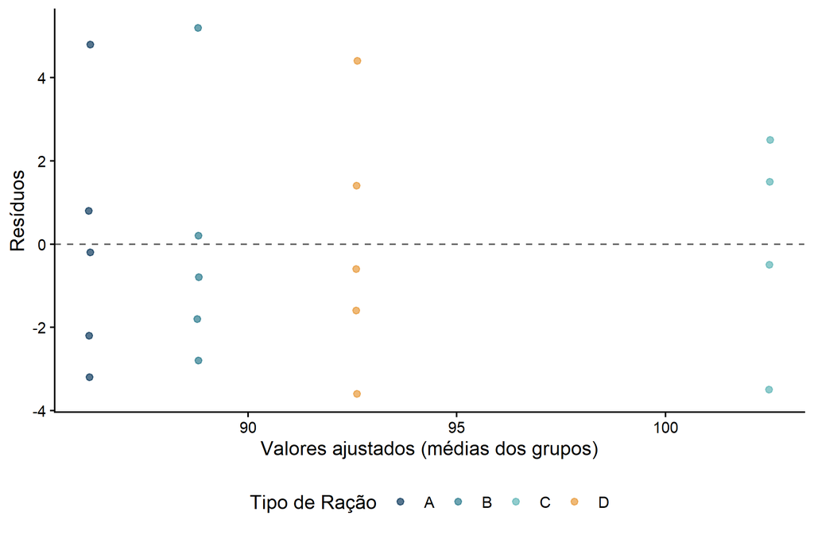

Figura 2: Resíduos versus valores ajustados; faixas de alturas muito diferentes sugerem variâncias desiguais.

```r
grafico_residuos
```

**Ver código de apresentação**

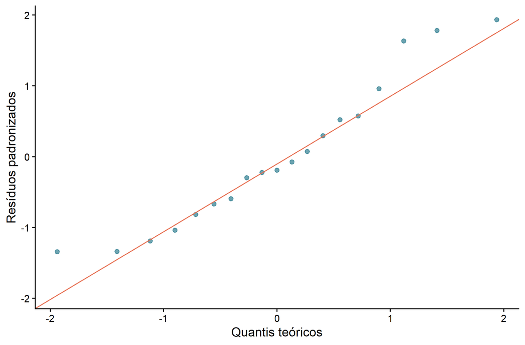

Figura 3: Gráfico Q-Q dos resíduos padronizados do modelo.

```r
grafico_qq
```

**Ver código de apresentação**

```r
flextable_ocean(tabela_testes)
```

Tabela 2: Testes de pressupostos e regra prática da razão de desvios-padrão, complementares à inspeção gráfica e ao delineamento.

| Pressuposto | Teste | Estatística | p |
| --- | --- | --- | --- |
| Normalidade dos resíduos | Shapiro-Wilk | W = 0,934 | 0,203 |
| Homogeneidade das variâncias | Levene | F(3, 15) = 0,02 | 0,997 |
| Homogeneidade das variâncias (regra prática) | Razão maior/menor DP | Razão = 1,18 | — |

Não houve evidência para rejeitar a normalidade dos resíduos. Shapiro-Wilk: W = 0,934; p = 0,203. Não houve evidência para rejeitar a igualdade das variâncias. Levene: F(3, 15) = 0,02; p = 0,997. Esses resultados não comprovam os pressupostos; a avaliação deve incluir os gráficos e o delineamento. A independência das observações depende de como os dados foram obtidos.

A Tabela 3 compara a ANOVA clássica, usada na análise, com a ANOVA de Welch, que não supõe variâncias iguais. É uma comparação apenas informativa: mostra o quanto a conclusão dependeria dessa escolha (Delacre et al., 2019). A Figura 5, no mesmo espírito de transparência, mostra cada observação como ponto, em vez de resumir os grupos em barras (Weissgerber et al., 2015). Os testes formais de pressupostos, por sua vez, complementam — sem substituir — a inspeção visual dos resíduos (Kozak & Piepho, 2018).

**Ver código de apresentação**

```r
flextable_ocean(tabela_comparativa)
```

Tabela 3: ANOVA clássica e ANOVA de Welch lado a lado. A análise usa a clássica; a comparação é apenas informativa.

| Aspecto | ANOVA clássica | ANOVA de Welch |
| --- | --- | --- |
| Suposição sobre as variâncias | Variâncias iguais entre os grupos | Não exige variâncias iguais |
| Estatística F | 24,38 | 24,24 |
| Graus de liberdade | 3; 15 | 3,0; 8,2 |
| p-valor | < 0,001 | < 0,001 |

# 5 Resultados: o que a ANOVA responde?

A Tabela 4 resume a decomposição da variabilidade que sustenta o teste F.

Em Peso (g), houve evidência de diferença entre as médias dos grupos de Tipo de Ração (F(3, 15) = 24,38; p < 0,001).

**Ver código de apresentação**

```r
flextable_ocean(tabela_anova_exibir)
```

Tabela 4: Análise de variância de um fator. GL: graus de liberdade; SQ: soma de quadrados; QM: quadrado médio.

| Fonte | GL | SQ | QM | F | p |
| --- | --- | --- | --- | --- | --- |
| Tipo de Ração | 3 | 662,20 | 220,73 | 24,38 | < 0,001 |
| Resíduo | 15 | 135,80 | 9,05 |  |  |

A Tabela 5 traz o tamanho do efeito medido pela análise.

O tamanho de efeito foi grande pela convenção de Cohen (η² = 0,830; ω² = 0,787), uma referência estatística, não biológica.

**Ver código de apresentação**

```r
flextable_ocean(tabela_efeito)
```

Tabela 5: Tamanho do efeito do fator.

| Medida | Valor | IC 95% | Leitura |
| --- | --- | --- | --- |
| η² | 0,830 | [0,649 a 1,000] | grande |
| ω² | 0,787 | [0,564 a 1,000] | correção do η² para amostras pequenas |

## 5.1 Comparações entre os grupos

As comparações dois a dois estão na Tabela 6 e o resumo com as letras na Tabela 7; a Figura 4 mostra cada diferença com seu intervalo de confiança e a Figura 5 apresenta as médias com seus intervalos.

Pelo teste de Tukey, grupos que compartilham uma letra não diferiram entre si ao nível adotado.

**Ver código de apresentação**

```r
flextable_ocean(tabela_tukey_exibir)
```

Tabela 6: Comparações entre pares pelo teste de Tukey, com intervalos de confiança e p-valores ajustados.

| Comparação | Diferença | IC 95% | p ajustado |
| --- | --- | --- | --- |
| B-A | 2,60 | -2,88 a 8,08 | 0,538 |
| C-A | 16,30 | 10,48 a 22,12 | < 0,001 |
| D-A | 6,40 | 0,92 a 11,88 | 0,020 |
| C-B | 13,70 | 7,88 a 19,52 | < 0,001 |
| D-B | 3,80 | -1,68 a 9,28 | 0,232 |
| D-C | -9,90 | -15,72 a -4,08 | < 0,001 |

**Ver código de apresentação**

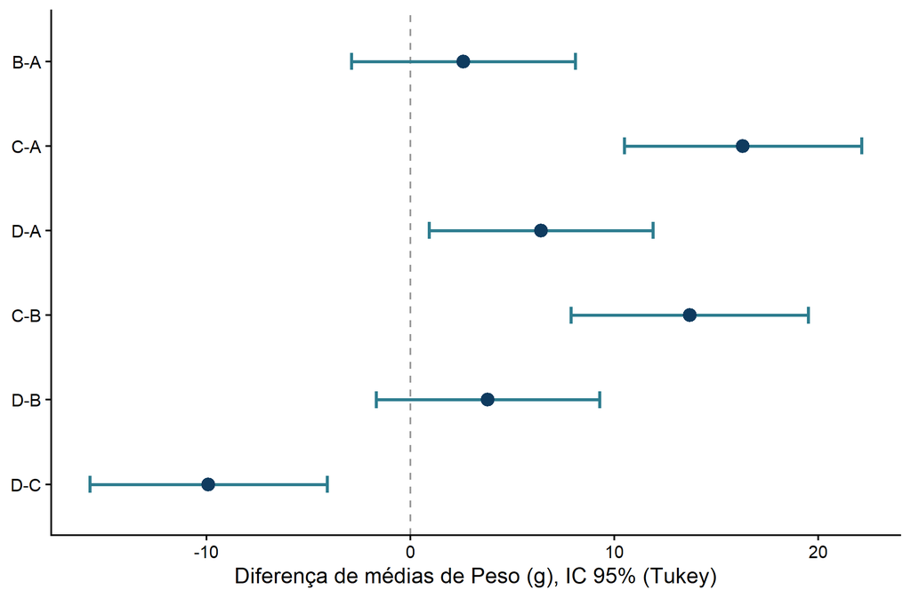

Figura 4: Diferenças entre pares com IC 95% ajustado por Tukey. IC que cruza o zero: sem diferença.

```r
grafico_pares
```

**Ver código de apresentação**

```r
flextable_ocean(tabela_resumo_exibir)
```

Tabela 7: Resumo por grupo com as letras do teste de Tukey.

| Tipo de Ração | n | Média | DP | EP | IC 95% | Tukey |
| --- | --- | --- | --- | --- | --- | --- |
| A | 5 | 86,20 | 3,11 | 1,39 | 82,33 a 90,07 | c |
| B | 5 | 88,80 | 3,11 | 1,39 | 84,93 a 92,67 | bc |
| C | 4 | 102,50 | 2,65 | 1,32 | 98,29 a 106,71 | a |
| D | 5 | 92,60 | 3,05 | 1,36 | 88,81 a 96,39 | b |

**Ver código de apresentação**

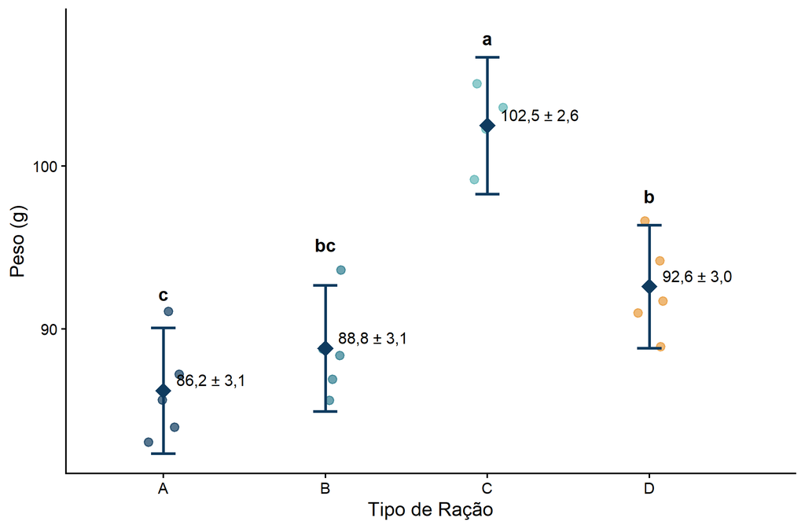

Figura 5: Média de cada grupo com intervalo de confiança; o rótulo mostra média ± desvio padrão e as letras indicam os grupos do teste de Tukey.

```r
grafico_barras
```

# 6 Discussão: voltar à pergunta biológica

*Sugestão para desenvolver a discussão: comente quais grupos se separam, o tamanho das diferenças e a leitura à luz do fenômeno investigado. Compare com estudos do mesmo organismo e inclua as referências consultadas.*

O p-valor expressa a compatibilidade dos dados com a hipótese nula; o tamanho de efeito descreve a magnitude da associação. A importância prática depende do contexto do estudo. O teste descreve diferenças entre os grupos; a atribuição de causa depende do delineamento e de como os dados foram obtidos.

Os testes formais não detectaram os desvios examinados, mas os gráficos e o delineamento continuam necessários.

# 7 Conclusão

Na amostra de 19 observações em 4 grupos, houve evidência de diferença entre as médias dos grupos (F(3, 15) = 24,38; p < 0,001; η² = 0,830). A interpretação deve considerar os pressupostos e o delineamento.

*Sugestão de redação: responda ao objetivo em poucas frases, considerando a magnitude das diferenças, a incerteza e os limites do delineamento. Não acrescente resultados que não tenham sido apresentados.*

# 8 Reproduzir e adaptar

Abra o arquivo `.Rproj`, reinicie o R e renderize este documento. Para alterar os cálculos, edite `R/analise.R`. Para amadurecer a argumentação científica, edite os QMDs. Preserve os dados de entrada e registre qualquer mudança feita na base preparada.

## 9 Referências

Delacre, M., Leys, C., Mora, Y. L., & Lakens, D. (2019). Taking parametric assumptions seriously: arguments for the use of Welch’s F-test instead of the classical F-test in one-way ANOVA. *International Review of Social Psychology*, *32*(1), 13. https://doi.org/10.5334/irsp.198

Fox, J., & Weisberg, S. (2019). *An R Companion to Applied Regression* (3º ed.). Sage.

Graves, S., Piepho, H.-P., & Selzer, L. (2026). *multcompView: Visualizations of Paired Comparisons*. Comprehensive R Archive Network (CRAN). https://doi.org/10.32614/CRAN.package.multcompView

Kozak, M., & Piepho, H.-P. (2018). What’s normal anyway? Residual plots are more telling than significance tests when checking ANOVA assumptions. *Journal of Agronomy and Crop Science*, *204*(1), 86–98. https://doi.org/10.1111/jac.12220

R Core Team. (2025). *R: A Language and Environment for Statistical Computing*. R Foundation for Statistical Computing. https://www.R-project.org/

Weissgerber, T. L., Milic, N. M., Winham, S. J., & Garovic, V. D. (2015). Beyond bar and line graphs: time for a new data presentation paradigm. *PLoS Biology*, *13*(4), e1002128. https://doi.org/10.1371/journal.pbio.1002128

Wickham, H. (2016). *ggplot2: Elegant Graphics for Data Analysis*. Springer-Verlag.

Zar, J. H. (2010). *Biostatistical Analysis* (5º ed.). Pearson Prentice Hall.